# ops-small

### 2. Пузырьком

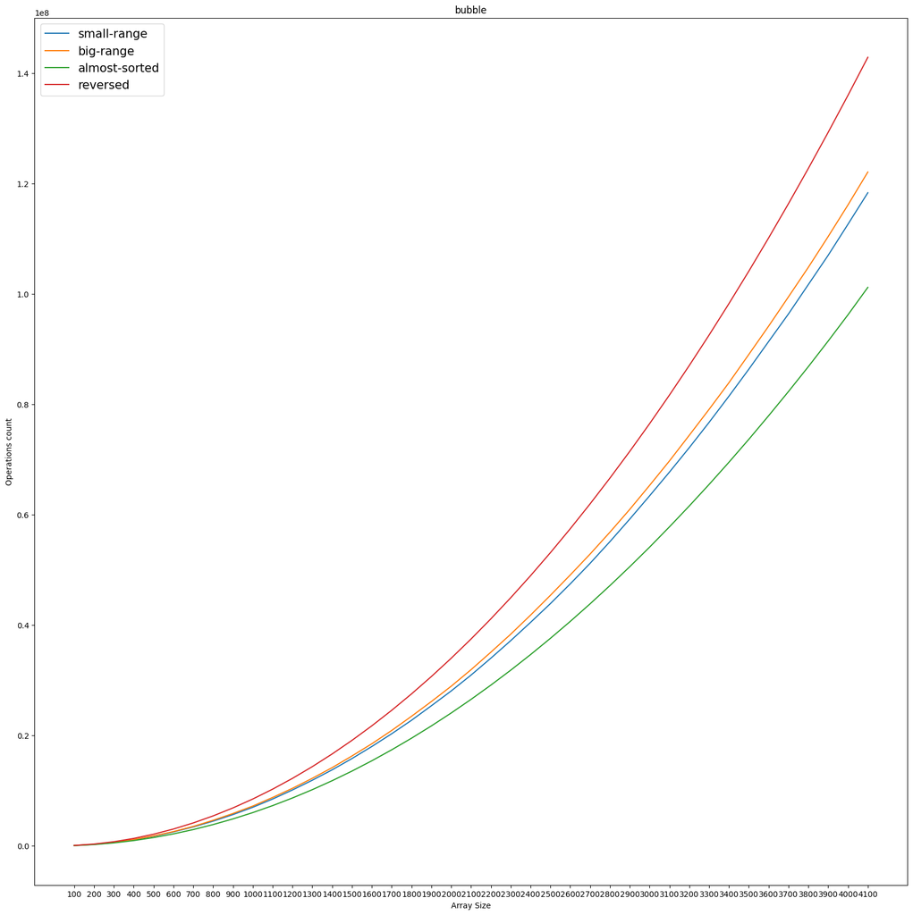

```python
print_sort(data, sorts[1])
```

**Вывод:** обычный чувствительный к порядку элементов пузырёк

### 3. Пузырьком с условием Айверсона 1

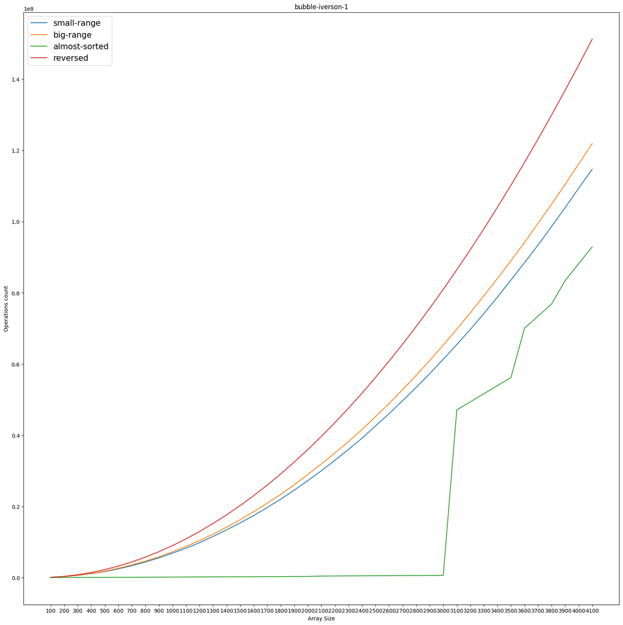

```python
print_sort(data, sorts[2])
```

**Вывод:** операций стало сравнительно меньше благодаря флагу с условием Айверсона 1!

### 4. Пузырьком с условием Айверсона 1 + 2

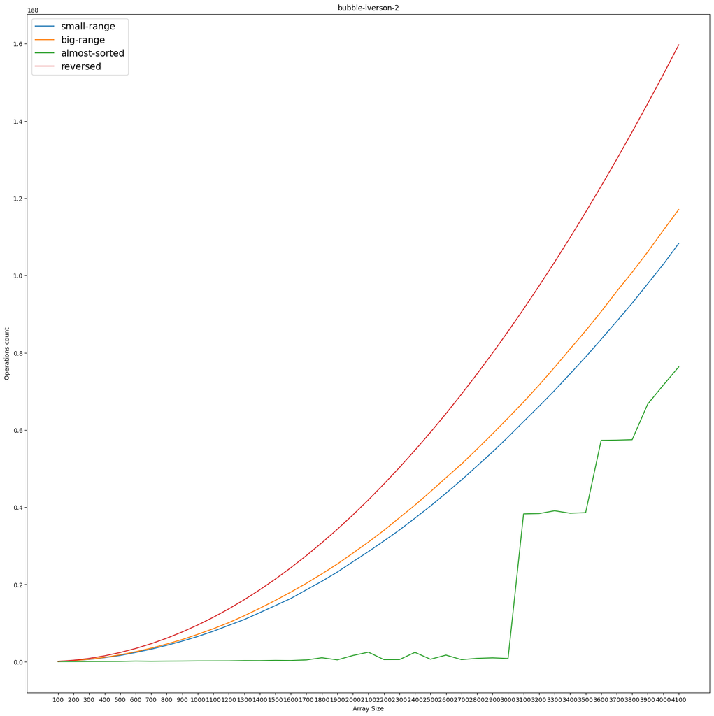

```python
print_sort(data, sorts[3])
```

**Вывод:** почти ничем не отличается от предыдущего

### 5. Простыми вставками

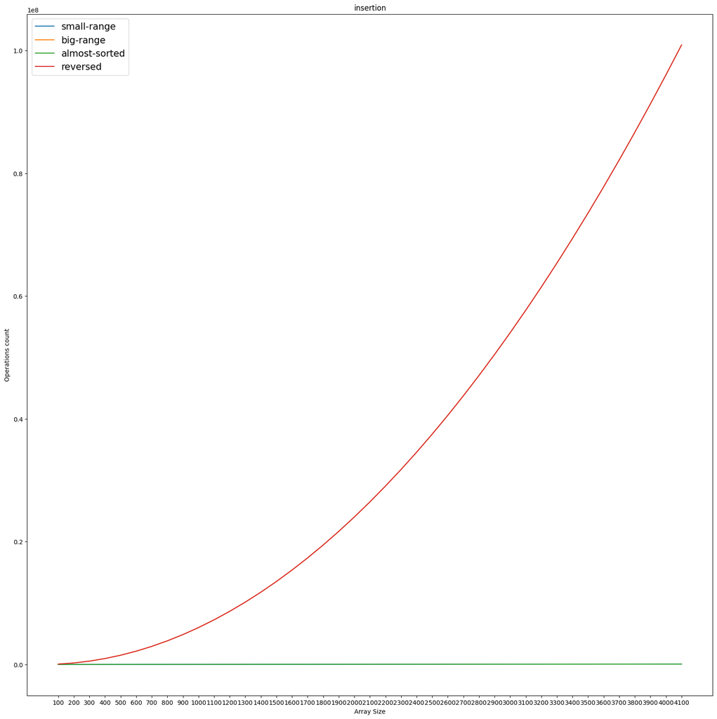

```python
print_sort(data, sorts[4])
```

**Вывод:** возможно, есть проблема со счётчиком операций (например, своп прибавляет несбалансированно большое число)

### 6. Бинарными вставками

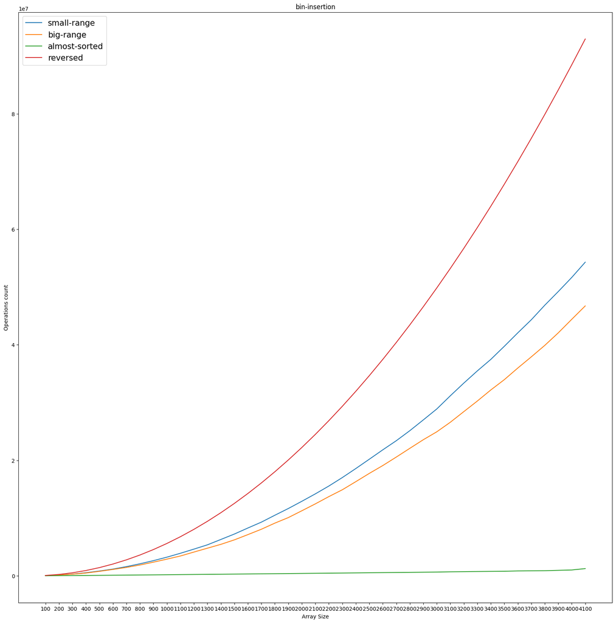

```python
print_sort(data, sorts[5])
```

**Вывод:** тут ожидаемый результат для сортировки вставками: порядок элементов влияет на количество свопов

### 7. Подсчётом

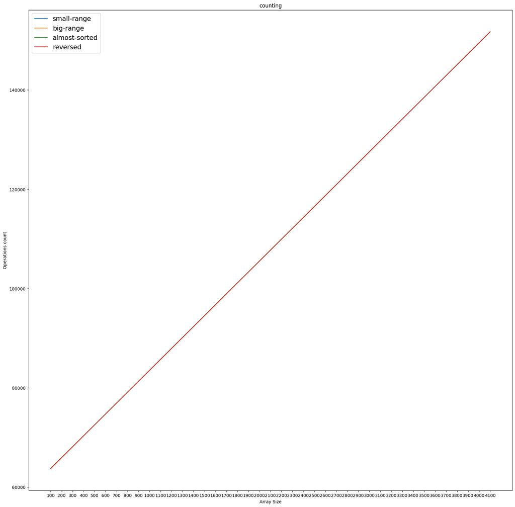

```python
print_sort(data, sorts[6])
```

**Вывод:** красивая линия)

### 8. Цифровая

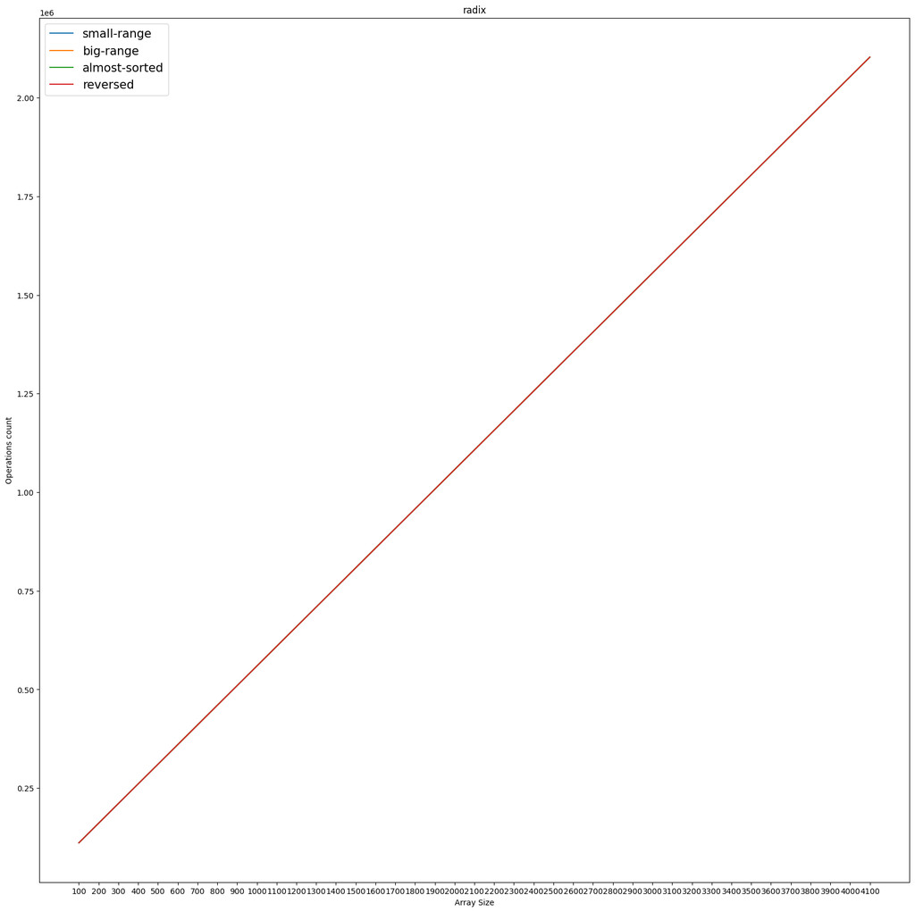

```python
print_sort(data, sorts[7])
```

**Вывод:** аналогично сортировке подсчёт показывает свою стабильность

### 9. Слиянием

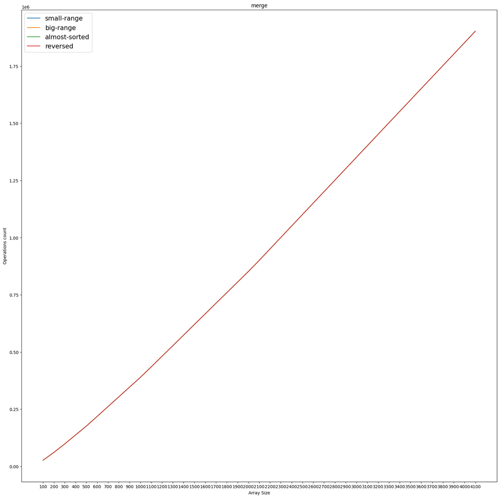

```python
print_sort(data, sorts[8])
```

**Вывод:** сортировка стабильна относительно входных элементов

### 10. Быстрая

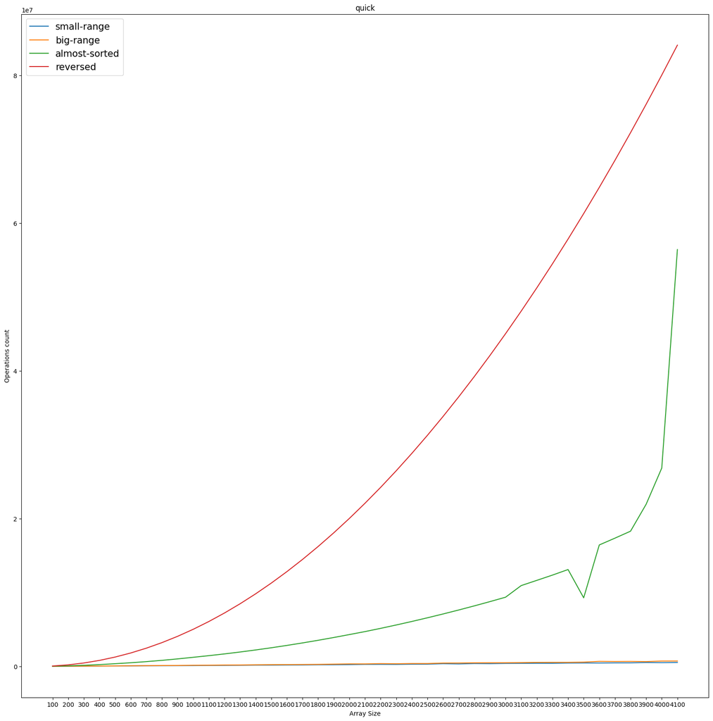

```python
print_sort(data, sorts[9])
```

**Вывод:** для частично упорядоченных последовательностей растёт количество операций ввиду из-за принципа обработки

### 11. Пирамидальная

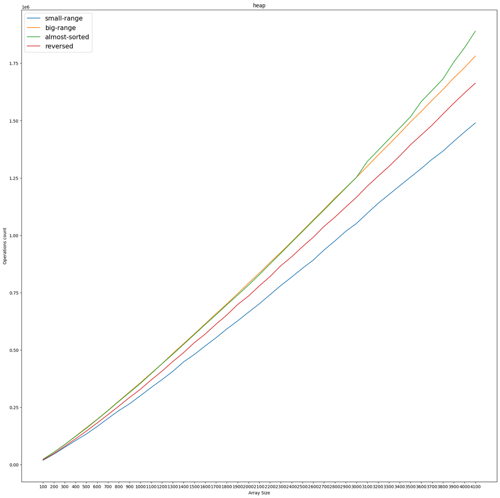

```python
print_sort(data, sorts[10])
```

**Вывод:** снова можно отметить количество влияение диапазона значений на сортировку

### 12. Шелла (последовательность Циура)

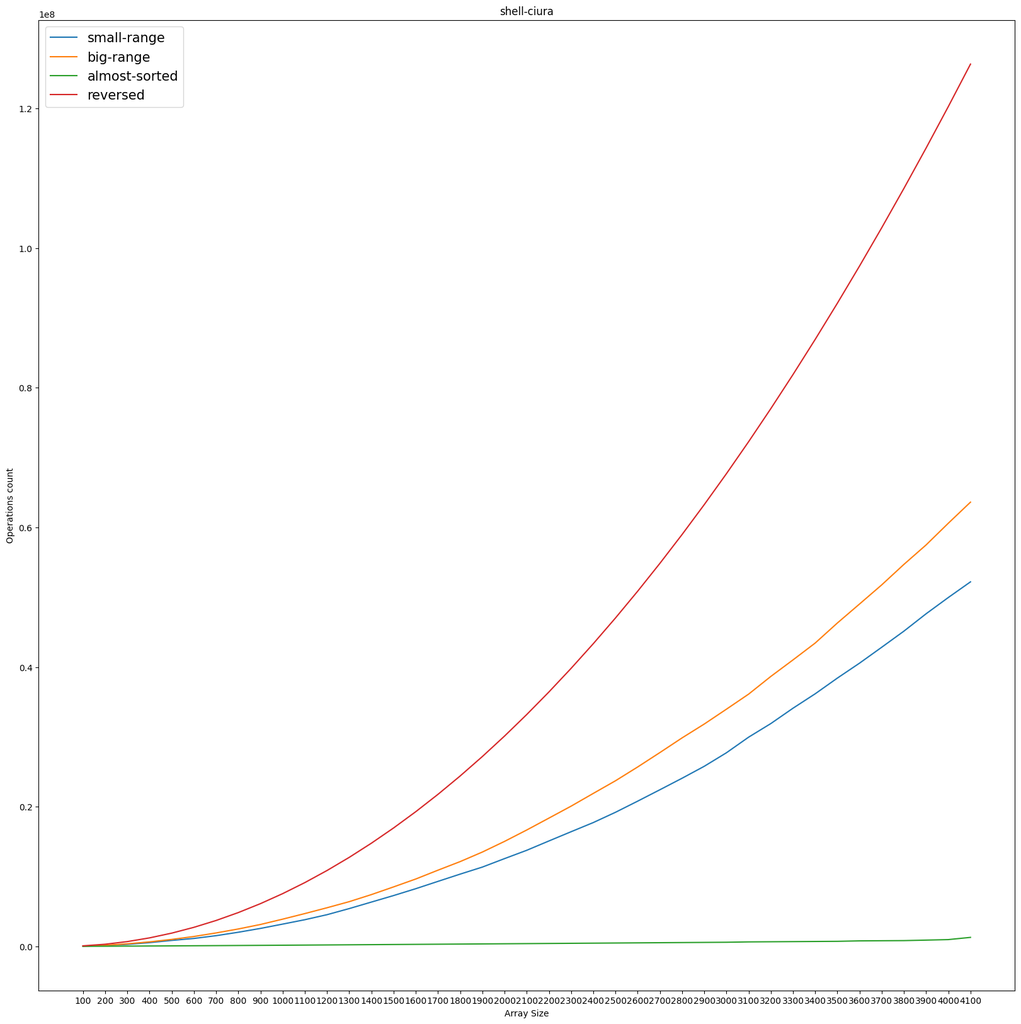

```python
print_sort(data, sorts[11])
```

**Вывод:** видимо влияние порядка элементов и их диапазона значений на количество операций

### 13. Шелла (последовательность Шелла)

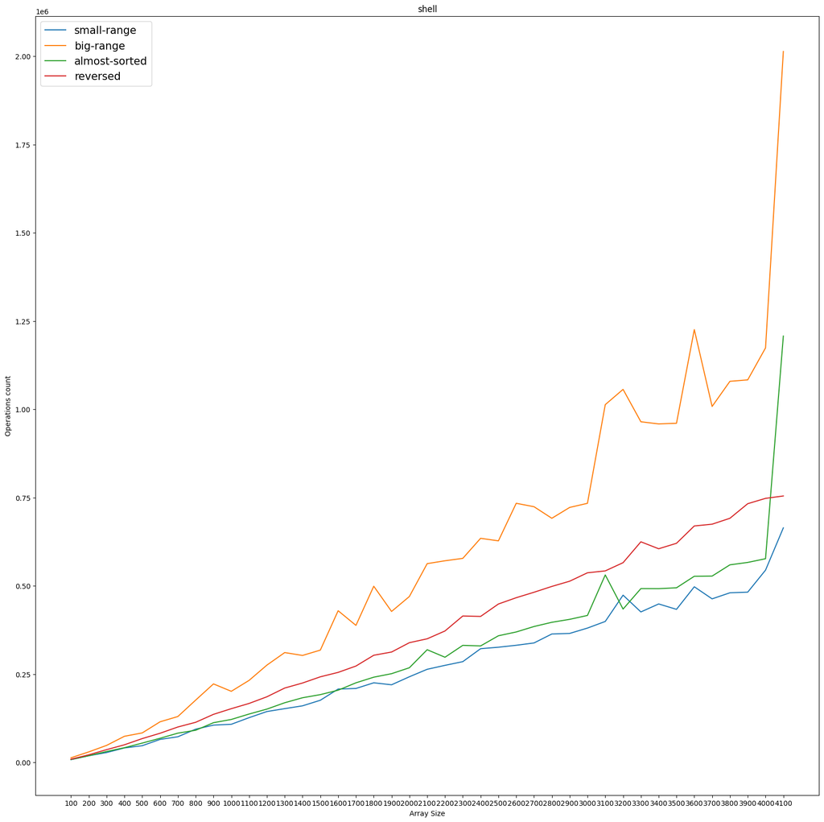

```python
print_sort(data, sorts[12])
```

**Вывод:** выбросы для числа операций объяснить не могу, вероятно, это связано с генерацией входных массивов

## По массивам

### 1. Случайные числа от 0 до 5

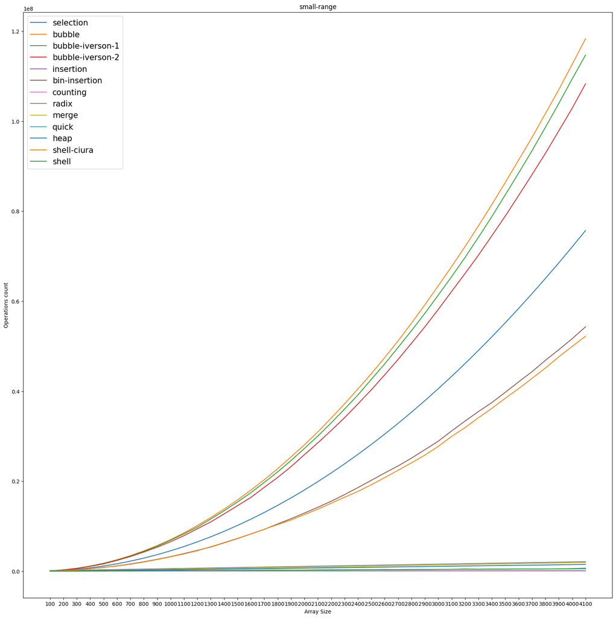

```python
print_array(data, arrays[0])
```

**Вывод:** красиво соответсвует теоретической асимптотите для сортировок

### 2. Случайные числа от 0 до 4000

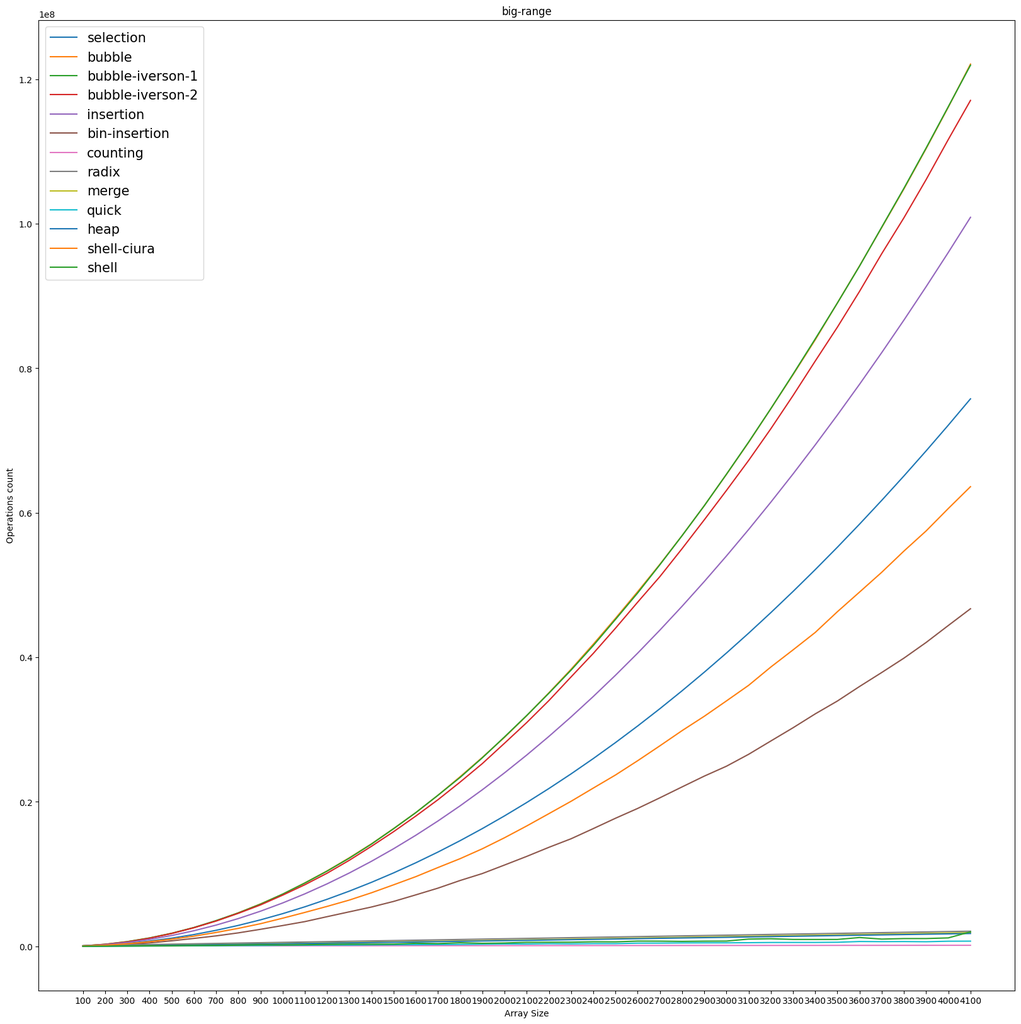

```python
print_array(data, arrays[1])
```

**Вывод:** из интересного -- снова `insertion` стал хуже по сравнению с предыдущим графиком

### 3. Почти отсортированный массив

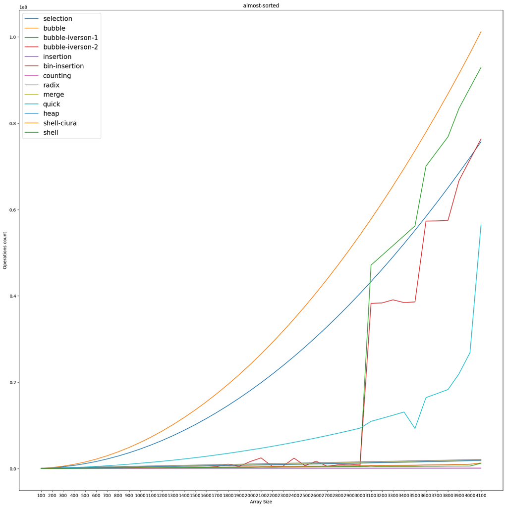

```python
print_array(data, arrays[2])
```

**Вывод:** снова деградировал `quick`, опять странности с пузырьком

### 4. Отсортированный в обратном порядке массив

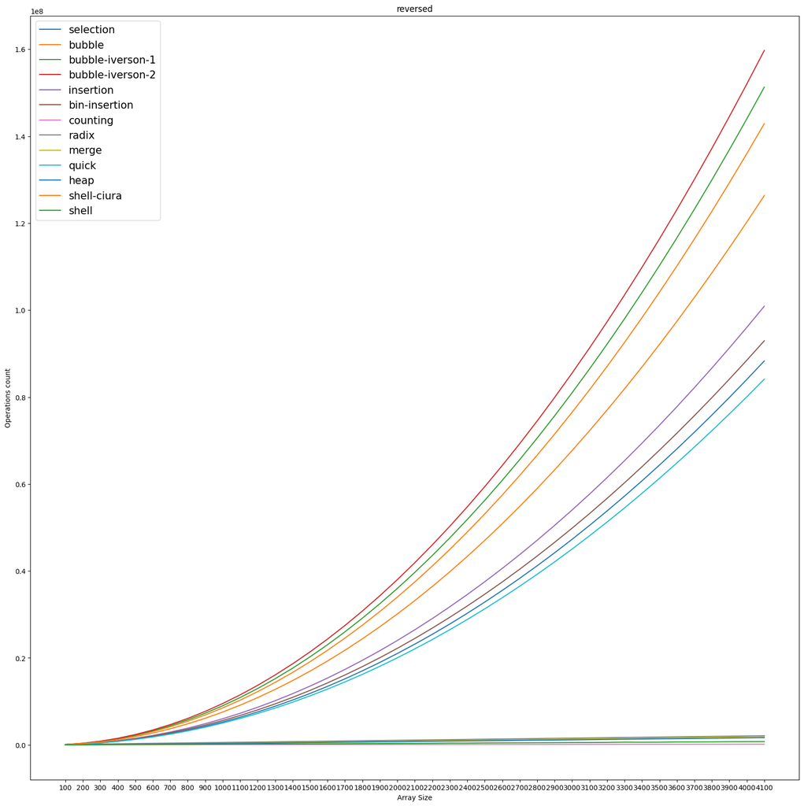

```python
print_array(data, arrays[3])
```

**Вывод:** хорошо заметна разница между линейными + `nlogn` сортировками и квадратичными